# Untitled

Mohd Azmi

06/12/2019

# Introduction

## Packages

```r
library(pacman)
p_load(dplyr, psych, knitr, ggplot2, broom, LogisticDx, generalhoslem, ResourceSelection)
```

## Data

```r
burnDS <- read.delim("BURN1000.txt", header = TRUE, sep = "\t", dec = ".")

burnDS2 <- burnDS %>%
  mutate(DcStat = factor(DEATH, labels = c("Alive", "Death")),
         Gender = factor(GENDER, labels = c("Female", "Male")),
         Ethnic = factor(RACEC, labels = c("Non-white", "White")),
         Inhale = factor(INH_INJ, labels = c("No", "Yes")),
         Flame = factor(FLAME, labels = c("No", "Yes"))) %>%
  dplyr::select(DcStat, AGE, Gender, Ethnic, TBSA, Inhale, Flame)
burnDS2
```

```
##      DcStat  AGE Gender    Ethnic TBSA Inhale Flame
## 1     Alive 26.6   Male     White 25.3     No   Yes
## 2     Alive  2.0 Female Non-white  5.0     No    No
## 3     Alive 22.0 Female Non-white  2.0     No    No
## 4     Alive 37.3   Male     White  2.0     No    No
## 5     Alive 52.1   Male     White  6.0     No   Yes
## 6     Alive 50.2   Male     White  7.0     No    No
## 7     Alive  2.5 Female Non-white  7.0     No    No
## 8     Alive 53.8 Female     White  0.9     No   Yes
## 9     Alive 31.9   Male     White  2.0     No    No
## 10    Alive 41.1   Male     White 22.0     No   Yes
## 11    Alive  3.8   Male Non-white  0.5     No    No
## 12    Alive  5.9   Male Non-white 30.5     No    No
## 13    Alive  1.9   Male Non-white 12.0     No    No
## 14    Alive 56.2   Male     White  7.0     No   Yes
```

[output cut: 986 more lines]

# Descriptive Analysis

## Data Summary

```r
burnDS2 %>%
  select_if(is.numeric) %>%
  summary()
```

```
##       AGE             TBSA
##  Min.   : 0.10   Min.   : 0.10
##  1st Qu.:10.85   1st Qu.: 2.50
##  Median :31.95   Median : 6.00
##  Mean   :33.29   Mean   :13.54
##  3rd Qu.:51.23   3rd Qu.:16.00
##  Max.   :89.70   Max.   :98.00
```

```r
burnDS2 %>%
  select_if(is.factor) %>%
  summary()
```

```
##    DcStat       Gender          Ethnic    Inhale    Flame
##  Alive:850   Female:295   Non-white:411   No :878   No :471
##  Death:150   Male  :705   White    :589   Yes:122   Yes:529
```

The age and total burn surface area distribution of the participant, group by discharge status was shown as below

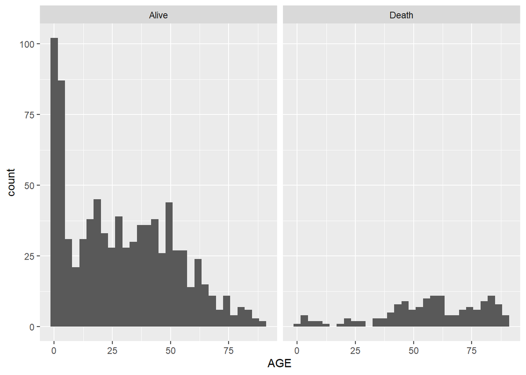

```r
ggplot(burnDS2, aes(x=AGE)) +
  geom_histogram() +
  facet_wrap(~DcStat)
```

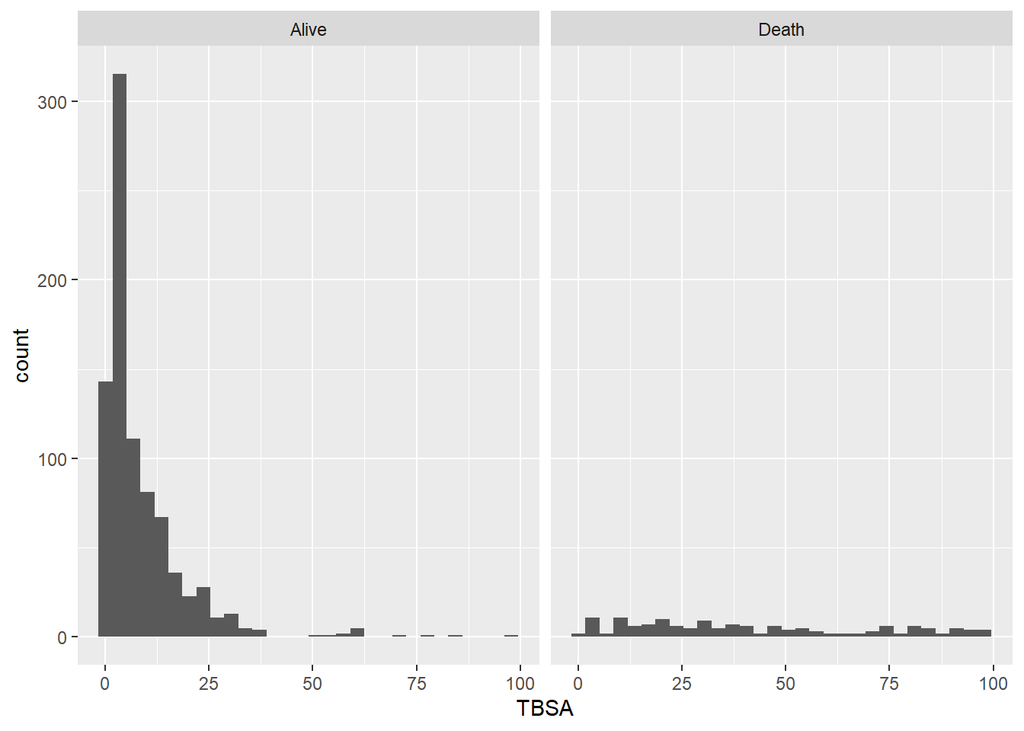

```r
ggplot(burnDS2, aes(x=TBSA)) +
  geom_histogram() +
  facet_wrap(~DcStat)
```

the distribution of gender, ethnicity, burn involved inhalation injury and flame involvement, group by discharge status, was shown as below

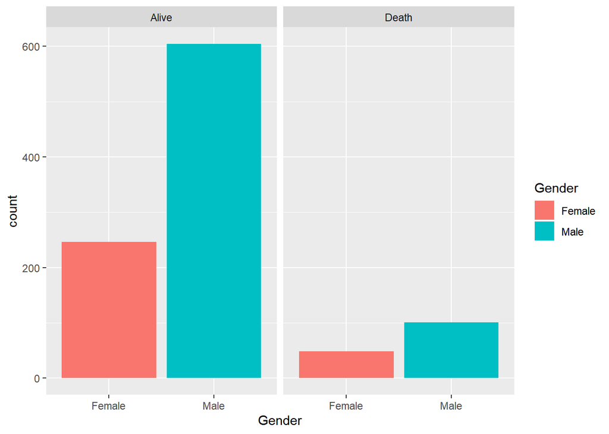

```r
ggplot(burnDS2, aes(x=Gender, fill=Gender)) +
  geom_bar() +
  facet_wrap(~DcStat)
```

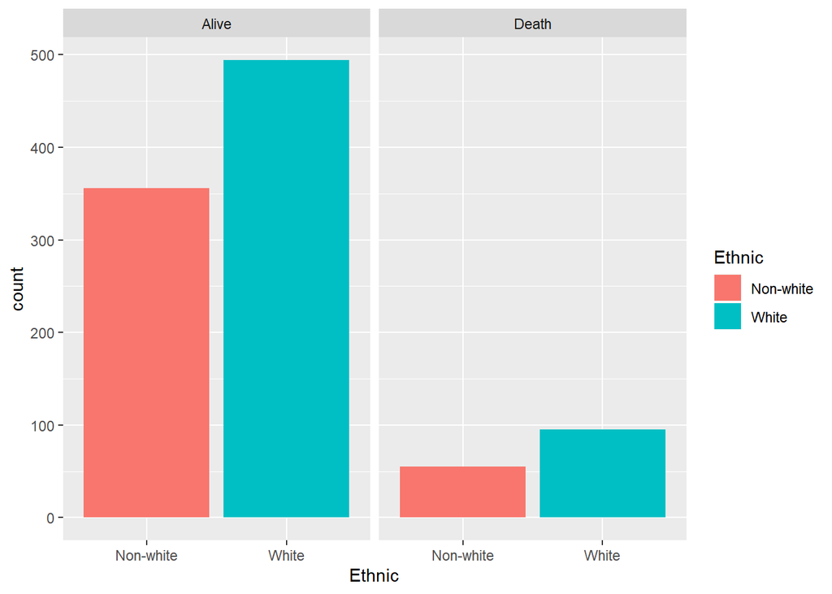

```r
ggplot(burnDS2, aes(x=Ethnic, fill=Ethnic)) +
  geom_bar() +
  facet_wrap(~DcStat)
```

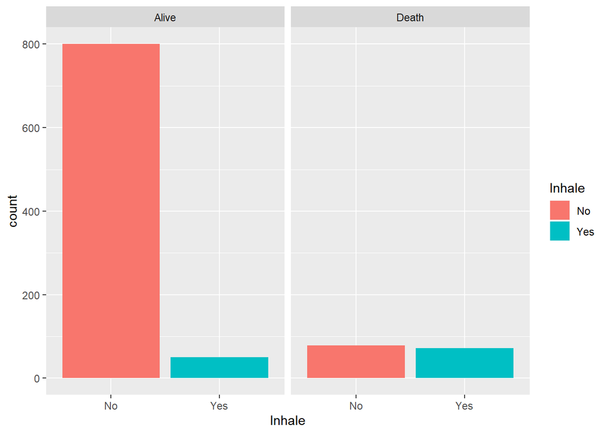

```r
ggplot(burnDS2, aes(x=Inhale, fill=Inhale)) +
  geom_bar() +
  facet_wrap(~DcStat)
```

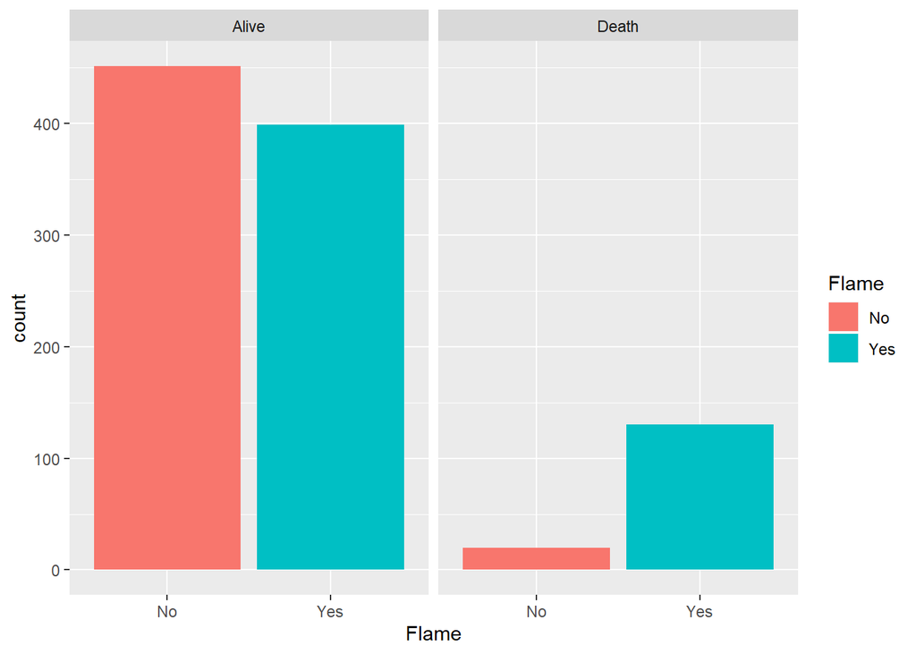

```r
ggplot(burnDS2, aes(x=Flame, fill=Flame)) +
  geom_bar() +
  facet_wrap(~DcStat)
```

# Univariable Analysis

Univariable analysis show that age, total burn surface area, inhalation injury and flame involvement was significant (at p < 0.05) in simple logistic regression. The detail of the simple logistic regression was shown as below.

```r
tidy(glm(DcStat ~ AGE, data = burnDS2, family = binomial))
```

```
## # A tibble: 2 x 5
##   term        estimate std.error statistic  p.value
##   <chr>          <dbl>     <dbl>     <dbl>    <dbl>
## 1 (Intercept)  -4.06     0.263       -15.4 8.27e-54
## 2 AGE           0.0533   0.00470      11.3 9.85e-30
```

```r
tidy(glm(DcStat ~ Gender, data = burnDS2, family = binomial))
```

```
## # A tibble: 2 x 5
##   term        estimate std.error statistic  p.value
##   <chr>          <dbl>     <dbl>     <dbl>    <dbl>
## 1 (Intercept)   -1.61      0.156   -10.3   6.09e-25
## 2 GenderMale    -0.175     0.190    -0.922 3.57e- 1
```

```r
tidy(glm(DcStat ~ Ethnic, data = burnDS2, family = binomial))
```

```
## # A tibble: 2 x 5
##   term        estimate std.error statistic  p.value
##   <chr>          <dbl>     <dbl>     <dbl>    <dbl>
## 1 (Intercept)   -1.87      0.145    -12.9  5.09e-38
## 2 EthnicWhite    0.219     0.183      1.20 2.32e- 1
```

```r
tidy(glm(DcStat ~ TBSA, data = burnDS2, family = binomial))
```

```
## # A tibble: 2 x 5
##   term        estimate std.error statistic  p.value
##   <chr>          <dbl>     <dbl>     <dbl>    <dbl>
## 1 (Intercept)  -3.35     0.176       -19.0 7.31e-81
## 2 TBSA          0.0854   0.00696      12.3 1.27e-34
```

```r
tidy(glm(DcStat ~ Inhale, data = burnDS2, family = binomial))
```

```
## # A tibble: 2 x 5
##   term        estimate std.error statistic  p.value
##   <chr>          <dbl>     <dbl>     <dbl>    <dbl>
## 1 (Intercept)    -2.33     0.119     -19.6 9.46e-86
## 2 InhaleYes       2.69     0.219      12.3 9.64e-35
```

```r
tidy(glm(DcStat ~ Flame, data = burnDS2, family = binomial))
```

```
## # A tibble: 2 x 5
##   term        estimate std.error statistic  p.value
##   <chr>          <dbl>     <dbl>     <dbl>    <dbl>
## 1 (Intercept)    -3.12     0.228    -13.6  2.40e-42
## 2 FlameYes        1.99     0.250      7.98 1.42e-15
```

```r
#all_SLR <- burnDS2 %>%
#  purrr::map(~glm(DcStat ~ .x, data = burnDS2, family = binomial, maxit=100)) %>%
#  purrr::map(tidy) %>%
#  bind_rows()
## unable to use purr::map function
```

# Multivariable Analysis

Several main effect model was establesh through variable selection.

## Preliminary Main Effect Models

Several Preliminary Main Effect Models will be compared to find Main Effect Models. All variable selected for model 1. Parameter for Multiple Logistic Regression for Model 1 was shown as below. Model 2 will have all variable in Model 1 except for gender variable, while model 3 will have all variable in Model 1 except for gender and flame involvement variable.

```r
model1 <- glm(DcStat ~ AGE + Gender + Ethnic + TBSA + Inhale + Flame,
              data = burnDS2,
              family = binomial)
summary(model1)
```

```
##
## Call:
## glm(formula = DcStat ~ AGE + Gender + Ethnic + TBSA + Inhale +
##     Flame, family = binomial, data = burnDS2)
##
## Deviance Residuals:
##      Min        1Q    Median        3Q       Max
## -3.01879  -0.24566  -0.08874  -0.03351   2.66144
##
## Coefficients:
##              Estimate Std. Error z value Pr(>|z|)
## (Intercept) -7.695153   0.691169 -11.134  < 2e-16 ***
## AGE          0.082890   0.008629   9.606  < 2e-16 ***
## GenderMale  -0.201494   0.307784  -0.655 0.512687
## EthnicWhite -0.701389   0.309781  -2.264 0.023565 *
## TBSA         0.089345   0.009087   9.832  < 2e-16 ***
## InhaleYes    1.365277   0.361780   3.774 0.000161 ***
## FlameYes     0.582578   0.354493   1.643 0.100298
## ---
## Signif. codes:  0 '***' 0.001 '**' 0.01 '*' 0.05 '.' 0.1 ' ' 1
##
## (Dispersion parameter for binomial family taken to be 1)
##
##     Null deviance: 845.42  on 999  degrees of freedom
## Residual deviance: 336.46  on 993  degrees of freedom
## AIC: 350.46
##
## Number of Fisher Scoring iterations: 7
```

```r
model2 <- glm(DcStat ~ AGE + Ethnic + TBSA + Inhale + Flame,
              data = burnDS2,
              family = binomial)
model3 <- glm(DcStat ~ AGE + Ethnic + TBSA + Inhale,
              data = burnDS2,
              family = binomial)
```

## Model Selection for Main Effect Model

Model comparison was done comparing between model 1 with model 2 and 3, using LR test method. There was no significant difference between model 1 with model 2 and 3, hence the simplest model, model 3 was taken as preliminary final model.

```r
anova(model1, model2, model3, test = "Chisq")
```

```
## Analysis of Deviance Table
##
## Model 1: DcStat ~ AGE + Gender + Ethnic + TBSA + Inhale + Flame
## Model 2: DcStat ~ AGE + Ethnic + TBSA + Inhale + Flame
## Model 3: DcStat ~ AGE + Ethnic + TBSA + Inhale
##   Resid. Df Resid. Dev Df Deviance Pr(>Chi)
## 1       993     336.46
## 2       994     336.89 -1  -0.4259  0.51401
## 3       995     339.78 -1  -2.8966  0.08877 .
## ---
## Signif. codes:  0 '***' 0.001 '**' 0.01 '*' 0.05 '.' 0.1 ' ' 1
```

```r
Burn_MainEffectModel <- model3
```

## Interaction

There are several interaction term between the variable, including

- age and ethnicity
- age and inhalation injury
- ethnicity and TBSA

the significant interactions were shown below.

```r
Model3_AgeEthnicInt <- glm(DcStat ~ AGE + Ethnic + TBSA + Inhale + AGE:Ethnic,
                           data = burnDS2,
                           family = binomial)
tidy(Model3_AgeEthnicInt)
```

```
## # A tibble: 6 x 5
##   term            estimate std.error statistic  p.value
##   <chr>              <dbl>     <dbl>     <dbl>    <dbl>
## 1 (Intercept)      -6.91     0.659      -10.5  1.12e-25
## 2 AGE               0.0704   0.0105       6.69 2.17e-11
## 3 EthnicWhite      -2.20     0.848       -2.60 9.42e- 3
## 4 TBSA              0.0919   0.00914     10.1  8.61e-24
## 5 InhaleYes         1.56     0.351        4.44 9.14e- 6
## 6 AGE:EthnicWhite   0.0280   0.0139       2.01 4.46e- 2
```

```r
Model3_AGEInhInt <- glm(DcStat ~ AGE + Ethnic + TBSA + Inhale + AGE:Inhale,
              data = burnDS2,
              family = binomial)
tidy(Model3_AGEInhInt)
```

```
## # A tibble: 6 x 5
##   term          estimate std.error statistic  p.value
##   <chr>            <dbl>     <dbl>     <dbl>    <dbl>
## 1 (Intercept)    -8.95     0.801      -11.2  5.80e-29
## 2 AGE             0.107    0.0116       9.29 1.58e-20
## 3 EthnicWhite    -0.666    0.303       -2.20 2.80e- 2
## 4 TBSA            0.0869   0.00919      9.45 3.38e-21
## 5 InhaleYes       4.58     0.887        5.16 2.47e- 7
## 6 AGE:InhaleYes  -0.0569   0.0149      -3.81 1.39e- 4
```

```r
Model3_EthnicTBSAInt <- glm(DcStat ~ AGE + Ethnic + TBSA + Inhale + Ethnic:TBSA,
              data = burnDS2,
              family = binomial)
tidy(Model3_EthnicTBSAInt)
```

```
## # A tibble: 6 x 5
##   term             estimate std.error statistic  p.value
##   <chr>               <dbl>     <dbl>     <dbl>    <dbl>
## 1 (Intercept)       -8.43     0.725     -11.6   2.90e-31
## 2 AGE                0.0876   0.00875    10.0   1.44e-23
## 3 EthnicWhite        0.262    0.454       0.578 5.63e- 1
## 4 TBSA               0.126    0.0171      7.36  1.90e-13
## 5 InhaleYes          1.51     0.350       4.30  1.71e- 5
## 6 EthnicWhite:TBSA  -0.0464   0.0176     -2.64  8.19e- 3
```

no interaction between

- age & tbsa
- ethnic & inhale injury
- tbsa & inhalation injury

```r
Model3_AgeTBSAInt <- glm(DcStat ~ AGE + Ethnic + TBSA + Inhale + AGE:TBSA,
              data = burnDS2,
              family = binomial)
summary(Model3_AgeTBSAInt)
```

```
##
## Call:
## glm(formula = DcStat ~ AGE + Ethnic + TBSA + Inhale + AGE:TBSA,
##     family = binomial, data = burnDS2)
##
## Deviance Residuals:
##      Min        1Q    Median        3Q       Max
## -3.08735  -0.25809  -0.09055  -0.03826   2.51691
##
## Coefficients:
##               Estimate Std. Error z value Pr(>|z|)
## (Intercept) -7.538e+00  6.934e-01 -10.871  < 2e-16 ***
## AGE          8.332e-02  1.080e-02   7.715 1.21e-14 ***
## EthnicWhite -6.255e-01  2.992e-01  -2.091   0.0366 *
## TBSA         8.825e-02  1.587e-02   5.561 2.68e-08 ***
## InhaleYes    1.531e+00  3.549e-01   4.315 1.59e-05 ***
## AGE:TBSA     5.424e-05  3.247e-04   0.167   0.8673
## ---
## Signif. codes:  0 '***' 0.001 '**' 0.01 '*' 0.05 '.' 0.1 ' ' 1
##
## (Dispersion parameter for binomial family taken to be 1)
##
##     Null deviance: 845.42  on 999  degrees of freedom
## Residual deviance: 339.76  on 994  degrees of freedom
## AIC: 351.76
##
## Number of Fisher Scoring iterations: 7
```

```r
Model3_EthnicInhInt <- glm(DcStat ~ AGE + Ethnic + TBSA + Inhale + Ethnic:Inhale,
              data = burnDS2,
              family = binomial)
summary(Model3_EthnicInhInt)
```

```
##
## Call:
## glm(formula = DcStat ~ AGE + Ethnic + TBSA + Inhale + Ethnic:Inhale,
##     family = binomial, data = burnDS2)
##
## Deviance Residuals:
##      Min        1Q    Median        3Q       Max
## -2.95979  -0.25821  -0.08930  -0.03552   2.63777
##
## Coefficients:
##                        Estimate Std. Error z value Pr(>|z|)
## (Intercept)           -7.774164   0.627585 -12.387  < 2e-16 ***
## AGE                    0.084790   0.008532   9.938  < 2e-16 ***
## EthnicWhite           -0.358508   0.344493  -1.041    0.298
## TBSA                   0.090228   0.009069   9.949  < 2e-16 ***
## InhaleYes              2.218135   0.566490   3.916 9.02e-05 ***
## EthnicWhite:InhaleYes -1.100771   0.685427  -1.606    0.108
## ---
## Signif. codes:  0 '***' 0.001 '**' 0.01 '*' 0.05 '.' 0.1 ' ' 1
##
## (Dispersion parameter for binomial family taken to be 1)
##
##     Null deviance: 845.42  on 999  degrees of freedom
## Residual deviance: 337.17  on 994  degrees of freedom
## AIC: 349.17
##
## Number of Fisher Scoring iterations: 7
```

```r
Model3_TBSAInhInt <- glm(DcStat ~ AGE + Ethnic + TBSA + Inhale + TBSA:Inhale,
              data = burnDS2,
              family = binomial)
summary(Model3_TBSAInhInt)
```

```
##
## Call:
## glm(formula = DcStat ~ AGE + Ethnic + TBSA + Inhale + TBSA:Inhale,
##     family = binomial, data = burnDS2)
##
## Deviance Residuals:
##      Min        1Q    Median        3Q       Max
## -2.97697  -0.25459  -0.08767  -0.03704   2.51857
##
## Coefficients:
##                 Estimate Std. Error z value Pr(>|z|)
## (Intercept)    -7.639102   0.612795 -12.466  < 2e-16 ***
## AGE             0.083563   0.008529   9.797  < 2e-16 ***
## EthnicWhite    -0.629800   0.299714  -2.101 0.035611 *
## TBSA            0.096599   0.011728   8.237  < 2e-16 ***
## InhaleYes       1.855482   0.510909   3.632 0.000282 ***
## TBSA:InhaleYes -0.014103   0.015797  -0.893 0.371965
## ---
## Signif. codes:  0 '***' 0.001 '**' 0.01 '*' 0.05 '.' 0.1 ' ' 1
##
## (Dispersion parameter for binomial family taken to be 1)
##
##     Null deviance: 845.42  on 999  degrees of freedom
## Residual deviance: 339.00  on 994  degrees of freedom
## AIC: 351
##
## Number of Fisher Scoring iterations: 7
```

## Preliminary Final Model

Since there were several interaction terms, the interaction terms were check for their effect toward the model. PrelimModel1 include all variables and interaction selected in main effect models, while PrelimModel2 include all variable in PrelimModel1, except for non-significant (at p < 0.05) interaction terms in PrelimModel1. Both PrelimModel1 and PrelimModel2 were compared.

Since there were no significant different between PrelimModel1 and PrelimModel2, PrelimModel2 were selected for Final Model

```r
PrelimModel1 <- glm(DcStat ~ AGE + Ethnic + TBSA + Inhale + AGE:Ethnic + AGE:Inhale + Ethnic:TBSA,
              data = burnDS2,
              family = binomial)
summary(PrelimModel1)
```

```
##
## Call:
## glm(formula = DcStat ~ AGE + Ethnic + TBSA + Inhale + AGE:Ethnic +
##     AGE:Inhale + Ethnic:TBSA, family = binomial, data = burnDS2)
##
## Deviance Residuals:
##      Min        1Q    Median        3Q       Max
## -2.91771  -0.21316  -0.05440  -0.01635   2.44943
##
## Coefficients:
##                  Estimate Std. Error z value Pr(>|z|)
## (Intercept)      -9.69216    1.24084  -7.811 5.67e-15 ***
## AGE               0.10979    0.01706   6.436 1.23e-10 ***
## EthnicWhite       0.28264    1.36692   0.207 0.836189
## TBSA              0.12124    0.02105   5.759 8.46e-09 ***
## InhaleYes         4.33243    0.90594   4.782 1.73e-06 ***
## AGE:EthnicWhite  -0.00220    0.01809  -0.122 0.903223
## AGE:InhaleYes    -0.05274    0.01535  -3.436 0.000591 ***
## EthnicWhite:TBSA -0.04405    0.02328  -1.892 0.058452 .
## ---
## Signif. codes:  0 '***' 0.001 '**' 0.01 '*' 0.05 '.' 0.1 ' ' 1
##
## (Dispersion parameter for binomial family taken to be 1)
##
##     Null deviance: 845.42  on 999  degrees of freedom
## Residual deviance: 319.66  on 992  degrees of freedom
## AIC: 335.66
##
## Number of Fisher Scoring iterations: 8
```

```r
PrelimModel2 <- glm(DcStat ~ AGE + Ethnic + TBSA + Inhale + AGE:Inhale,
              data = burnDS2,
              family = binomial)
summary(PrelimModel2)
```

```
##
## Call:
## glm(formula = DcStat ~ AGE + Ethnic + TBSA + Inhale + AGE:Inhale,
##     family = binomial, data = burnDS2)
##
## Deviance Residuals:
##      Min        1Q    Median        3Q       Max
## -2.74143  -0.22561  -0.05657  -0.01909   2.51369
##
## Coefficients:
##                Estimate Std. Error z value Pr(>|z|)
## (Intercept)   -8.945345   0.800930 -11.169  < 2e-16 ***
## AGE            0.107405   0.011565   9.287  < 2e-16 ***
## EthnicWhite   -0.665921   0.302970  -2.198 0.027951 *
## TBSA           0.086860   0.009191   9.450  < 2e-16 ***
## InhaleYes      4.576668   0.886949   5.160 2.47e-07 ***
## AGE:InhaleYes -0.056877   0.014930  -3.810 0.000139 ***
## ---
## Signif. codes:  0 '***' 0.001 '**' 0.01 '*' 0.05 '.' 0.1 ' ' 1
##
## (Dispersion parameter for binomial family taken to be 1)
##
##     Null deviance: 845.42  on 999  degrees of freedom
## Residual deviance: 325.19  on 994  degrees of freedom
## AIC: 337.19
##
## Number of Fisher Scoring iterations: 8
```

```r
anova(PrelimModel1, PrelimModel2, test = "Chisq")
```

```
## Analysis of Deviance Table
##
## Model 1: DcStat ~ AGE + Ethnic + TBSA + Inhale + AGE:Ethnic + AGE:Inhale +
##     Ethnic:TBSA
## Model 2: DcStat ~ AGE + Ethnic + TBSA + Inhale + AGE:Inhale
##   Resid. Df Resid. Dev Df Deviance Pr(>Chi)
## 1       992     319.66
## 2       994     325.19 -2  -5.5374  0.06274 .
## ---
## Signif. codes:  0 '***' 0.001 '**' 0.01 '*' 0.05 '.' 0.1 ' ' 1
```

## Model Assessment

For Preliminary Final model, the variables included in the models are age, ethnicity, TBSA, Inhalation Injury and Age x Inhalation injury. Goodness of fit assessments were done to assess the Preliminary Final Model.

```r
Burn_PrelimFinalModel <- glm(DcStat ~ AGE + Ethnic + TBSA + Inhale + AGE:Inhale,
              data = burnDS2,
              family = binomial)
```

The model was considered fit, despite having significant Hosmer Lemeshow Test. The Area Under ROC curve was 96.8% (95% CI: 95.8%, 97.8%). Hosmer Lemeshow Test, the contingency table and ROC Curve Plot were shown below.

```r
hoslem.test(burnDS2$DcStat, fitted(Burn_PrelimFinalModel), g = 10)
```

```
##
##  Hosmer and Lemeshow goodness of fit (GOF) test
##
## data:  burnDS2$DcStat, fitted(Burn_PrelimFinalModel)
## X-squared = 1000, df = 8, p-value < 2.2e-16
```

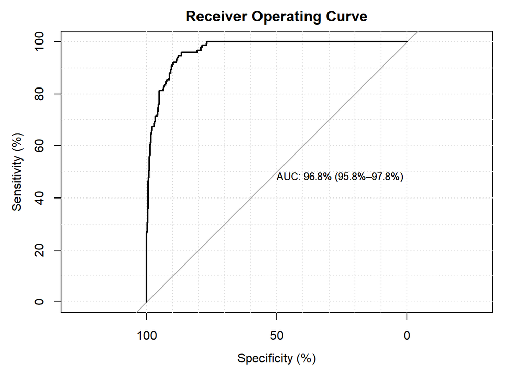

```r
GOF_PrelimFinalModel <- gof(Burn_PrelimFinalModel, plotROC = T)
```

```r
GOF_PrelimFinalModel$ctHL
```

```
##            P y1       y1hat  y0    y0hat   n         Pbar
##  1: 0.000182  0  0.01258708 100 99.98741 100 0.0001258708
##  2: 0.000378  0  0.02684011 100 99.97316 100 0.0002684011
##  3: 0.000961  0  0.06298428 100 99.93702 100 0.0006298428
##  4:  0.00303  0  0.17574404 100 99.82426 100 0.0017574404
##  5:  0.00875  0  0.50629462 100 99.49371 100 0.0050629462
##  6:    0.025  0  1.52246016 100 98.47754 100 0.0152246016
##  7:   0.0694  6  4.25034345  94 95.74966 100 0.0425034345
##  8:    0.225 16 13.39895535  84 86.60104 100 0.1339895535
##  9:    0.625 40 41.01299279  60 58.98701 100 0.4101299279
## 10:    0.999 88 89.03079814  12 10.96920 100 0.8903079814
```

# Final Model

```r
Burn_FinalModel <- Burn_PrelimFinalModel
```